# Coding challanges for Session Three

Akos Mate

2020 July

# Excercise 1 - Reshaping data

> 1. load a data set on financial data of Microsoft and Tesla from the `03_data_wrangling1\data` folder from the file `stock_data.csv`.
> 2. The dataset contains 3 columns: a date and closing prices for Tesla and Microsoft shares.
> 3. Use the `gather()` function to create a new data frame, with 3 variables: date, company and stock_closing. You should see something similar than below.

```r
head(stock_tidy)
```

| date | company | stock_closing |
| --- | --- | --- |
| 2016-01-11 | TSLA.Close | 207.85 |
| 2016-01-12 | TSLA.Close | 209.97 |
| 2016-01-13 | TSLA.Close | 200.31 |
| 2016-01-14 | TSLA.Close | 206.18 |
| 2016-01-15 | TSLA.Close | 204.99 |
| 2016-01-19 | TSLA.Close | 204.72 |

> 4. As a refresher, use the `group_by()` and `summarise()` functions to see the minimum, maximum and mean closing prices for the two company. Use the `%>%` pipe operator! You should get something similar as below.

The desired output:

| company | min | max | mean |
| --- | --- | --- | --- |
| MSFT.Close | 48.43 | 88.28 | 63.98619 |
| TSLA.Close | 143.67 | 385.00 | 263.09780 |

> 5. Finally, use `ggplot2` to visualise the closing prices of the two company. Use the `geom_line()`! You should get a similar plot as below.

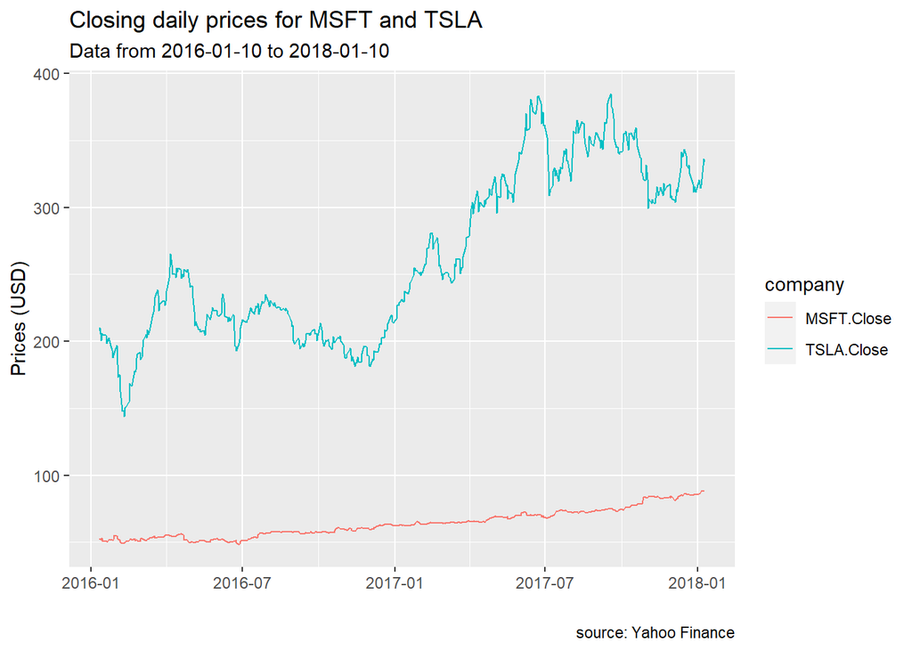

# Excercise 2 - Appending data

> 1. load additional data from `03_data_wrangling1\data` folder’s `stock_data2.csv` file and perform the same reshaping with the `gather()` function as during our session.
> 2. then use `bind_rows()` to add the two new company to the previous `stock_tidy` data frame, by creating a new data frame, called `stock_tidy2`.
> 3. Use the %>% to pipe together your steps. Bonus: You can use the `unique()` function to check how many unique value you have in a given column.

The output looks like this:

| date | company | stock_closing |
| --- | --- | --- |
| 2016-01-11 | AAPL.Close | 98.53 |
| 2016-01-12 | AAPL.Close | 99.96 |
| 2016-01-13 | AAPL.Close | 97.39 |
| 2016-01-14 | AAPL.Close | 99.52 |
| 2016-01-15 | AAPL.Close | 97.13 |

Unique companies in the dataset:

```
#> [1] "AAPL.Close" "F.Close"    "TSLA.Close" "MSFT.Close"
```